# 01.01-Credit-Scoring

## Исследование надёжности заёмщиков

Заказчик — кредитный отдел банка. Нужно разобраться, влияет ли семейное положение и количество детей клиента на факт погашения кредита в срок. Входные данные от банка — статистика о платёжеспособности клиентов.

Результаты исследования будут учтены при построении модели [**кредитного скоринга**](https://ru.wikipedia.org/wiki/%D0%9A%D1%80%D0%B5%D0%B4%D0%B8%D1%82%D0%BD%D1%8B%D0%B9_%D1%81%D0%BA%D0%BE%D1%80%D0%B8%D0%BD%D0%B3) — специальной системы, которая оценивает способность потенциального заёмщика вернуть кредит банку.

### Шаг 1. Откройте файл с данными и изучите общую информацию

**Импортируем библиотеку Pandas.** Официальная документация по библиотеке на английском языке [здесь](https://pandas.pydata.org/docs/).

Интересные материалы на русском языке:

- [Руководство по использованию pandas для анализа больших наборов данных](https://habr.com/ru/company/ruvds/blog/442516/)
- [Введение в анализ данных с помощью Pandas](https://habr.com/ru/post/196980/)

```python
import pandas as pd
```

**Откроем таблицу**, загрузив её из файла с помощью функции [`read_csv`](https://pandas.pydata.org/docs/reference/api/pandas.read_csv.html). Файл можно также скачать через Интернет по [адресу](https://yandex.ru/).

```python
data = pd.read_csv('/datasets/data.csv')
```

Выведем **первые 10 записей** таблицы с помощью [`head()`](https://pandas.pydata.org/docs/reference/api/pandas.DataFrame.head.html):

```python
data.head(10)
```

|  | children | days_employed | dob_years | education | education_id | family_status | family_status_id | gender | income_type | debt | total_income | purpose |
| --- | --- | --- | --- | --- | --- | --- | --- | --- | --- | --- | --- | --- |
| 0 | 1 | -8437.673028 | 42 | высшее | 0 | женат / замужем | 0 | F | сотрудник | 0 | 253875.639453 | покупка жилья |
| 1 | 1 | -4024.803754 | 36 | среднее | 1 | женат / замужем | 0 | F | сотрудник | 0 | 112080.014102 | приобретение автомобиля |
| 2 | 0 | -5623.422610 | 33 | Среднее | 1 | женат / замужем | 0 | M | сотрудник | 0 | 145885.952297 | покупка жилья |
| 3 | 3 | -4124.747207 | 32 | среднее | 1 | женат / замужем | 0 | M | сотрудник | 0 | 267628.550329 | дополнительное образование |
| 4 | 0 | 340266.072047 | 53 | среднее | 1 | гражданский брак | 1 | F | пенсионер | 0 | 158616.077870 | сыграть свадьбу |
| 5 | 0 | -926.185831 | 27 | высшее | 0 | гражданский брак | 1 | M | компаньон | 0 | 255763.565419 | покупка жилья |
| 6 | 0 | -2879.202052 | 43 | высшее | 0 | женат / замужем | 0 | F | компаньон | 0 | 240525.971920 | операции с жильем |
| 7 | 0 | -152.779569 | 50 | СРЕДНЕЕ | 1 | женат / замужем | 0 | M | сотрудник | 0 | 135823.934197 | образование |
| 8 | 2 | -6929.865299 | 35 | ВЫСШЕЕ | 0 | гражданский брак | 1 | F | сотрудник | 0 | 95856.832424 | на проведение свадьбы |
| 9 | 0 | -2188.756445 | 41 | среднее | 1 | женат / замужем | 0 | M | сотрудник | 0 | 144425.938277 | покупка жилья для семьи |

Выведем **общую информацию** о наборе данных с помощью [`info`](https://pandas.pydata.org/docs/reference/api/pandas.DataFrame.info.html):

```python
data.info()
```

```
<class 'pandas.core.frame.DataFrame'>
RangeIndex: 21525 entries, 0 to 21524
Data columns (total 12 columns):
 #   Column            Non-Null Count  Dtype
---  ------            --------------  -----
 0   children          21525 non-null  int64
 1   days_employed     19351 non-null  float64
 2   dob_years         21525 non-null  int64
 3   education         21525 non-null  object
 4   education_id      21525 non-null  int64
 5   family_status     21525 non-null  object
 6   family_status_id  21525 non-null  int64
 7   gender            21525 non-null  object
 8   income_type       21525 non-null  object
 9   debt              21525 non-null  int64
 10  total_income      19351 non-null  float64
 11  purpose           21525 non-null  object
dtypes: float64(2), int64(5), object(5)
memory usage: 2.0+ MB
```

**Рассмотрим распределения** числовых полей набора данных с помощью функции [`describe`](https://pandas.pydata.org/docs/reference/api/pandas.DataFrame.describe.html).

```python
data.describe()
```

|  | children | days_employed | dob_years | education_id | family_status_id | debt | total_income |
| --- | --- | --- | --- | --- | --- | --- | --- |
| count | 21525.000000 | 19351.000000 | 21525.000000 | 21525.000000 | 21525.000000 | 21525.000000 | 1.935100e+04 |
| mean | 0.538908 | 63046.497661 | 43.293380 | 0.817236 | 0.972544 | 0.080883 | 1.674223e+05 |
| std | 1.381587 | 140827.311974 | 12.574584 | 0.548138 | 1.420324 | 0.272661 | 1.029716e+05 |
| min | -1.000000 | -18388.949901 | 0.000000 | 0.000000 | 0.000000 | 0.000000 | 2.066726e+04 |
| 25% | 0.000000 | -2747.423625 | 33.000000 | 1.000000 | 0.000000 | 0.000000 | 1.030532e+05 |
| 50% | 0.000000 | -1203.369529 | 42.000000 | 1.000000 | 0.000000 | 0.000000 | 1.450179e+05 |
| 75% | 1.000000 | -291.095954 | 53.000000 | 1.000000 | 1.000000 | 0.000000 | 2.034351e+05 |
| max | 20.000000 | 401755.400475 | 75.000000 | 4.000000 | 4.000000 | 1.000000 | 2.265604e+06 |

**Бегло изучим общую информацию о таблице.** Проверим соответствие полей спецификации задания. Результат проверки сведем в таблицу.

[output not shown]

**Оценим количество и долю дубликатов** в массиве данных с помощью функции [`duplicated`](https://pandas.pydata.org/docs/reference/api/pandas.DataFrame.duplicated.html):

```python
print('Количество записей, имеющих полные дубликаты:', data.duplicated().sum())
```

```
Количество записей, имеющих полные дубликаты: 54
```

```python
print('Доля полных дубликатов: {:.2%}'.format(data.duplicated().sum() / data.shape[0]))
```

```
Доля полных дубликатов: 0.25%
```

### Вывод

- Полученный файл имеет корректный формат, удобный для обработки с помощью библиотеки Pandas.
- Названия столбцов не искажены и могут быть использованы для упрощенной адресации Pandas в виде `data.dob_years`, а не только `data['dob_years']`. Предобработка названий столбцов не требуется.
- Доля полных дубликатов строк невелика. Их наличие скорее не окажет негативное влияние на дальнейшую работу. Тем не менее, необходимо выбрать наиболее подходящий метод обработки дубликатов строк и повторяющихся значений в некоторых столбцах.
- Массив данных в целом пригоден для анализа, но требует предобработки, включая как минимум:
  - устранение пропусков в полях `days_employed` (общий трудовой стаж в днях) и `total_income` (ежемесячный доход);
  - изменение типа поля `days_employed` (общий трудовой стаж в днях);
  - фильтрацию отрицательных и слишком больших значений в поле `children` (количество детей в семье);
  - удаление дубликатов в столбце `education` (уровень образования клиента), который содержит одинаковый по смыслу текст, написанный строчными и прописными букв;
  - категоризацию полей `dob_years` (возраст клиента в годах), `income_type` (тип занятости) и др.;
  - лемматизацию поля `purpose` (цель получения кредита);
  - проверку и удаление возможно дублирующих друг друга столбцов - `education` (уровень образования клиента) и `education_id` (идентификатор уровня образования), `family_status` (семейное положение) и `family_status_id` (идентификатор семейного положения).
- Целесообразно вычисление по полученным данным новых характеристик претендента на получение кредита для дальнейшего анализа, например, среднего дохода на члена семьи претендента (с учетом семейного положения и количества детей).

### Шаг 2. Предобработка данных

### Обработка пропусков

#### Поле days_employed (общий трудовой стаж в днях)

Поле `days_employed` выглядит наиболее запутанным. Его тип не соответствует спецификации. Должен быть целочисленным, реально в массиве данных содержатся положительные и отрицательные вещественные числа с большим разбросом и пропусками:

Проведем детальное изучение структуры полученных данных для определения оптимальных способов их предобработки в интересах облегчения последующего анализа. Используем условную индексацию и функции [`value_counts`](https://pandas.pydata.org/docs/reference/api/pandas.DataFrame.value_counts.html) и [`describe`](https://pandas.pydata.org/docs/reference/api/pandas.DataFrame.describe.html).

Проверим наличие связи поля `days_employed` с полем `income_type` (тип занятости).

Отрицательные значения `days_employed` только у работающих, включая находящихся в декрете (с сохранением заработной платы), предпринимателя и студента:

```python
data[data.days_employed < 0]['income_type'].value_counts()
```

```
сотрудник          10014
компаньон           4577
госслужащий         1312
в декрете              1
предприниматель        1
студент                1
Name: income_type, dtype: int64
```

```python
data[data.days_employed < 0]['days_employed'].describe()
```

```
count    15906.000000
mean     -2353.015932
std       2304.243851
min     -18388.949901
25%      -3157.480084
50%      -1630.019381
75%       -756.371964
max        -24.141633
Name: days_employed, dtype: float64
```

Положительные значения `days_employed` характерны только для пенсионеров и безработных. При этом среднее значение стремится к 365004 дням (примерно 1000 лет):

```python
data[data.days_employed > 0]['income_type'].value_counts()
```

```
пенсионер      3443
безработный       2
Name: income_type, dtype: int64
```

```python
data[data.days_employed > 0]['days_employed'].describe()
```

```
count      3445.000000
mean     365004.309916
std       21075.016396
min      328728.720605
25%      346639.413916
50%      365213.306266
75%      383246.444219
max      401755.400475
Name: days_employed, dtype: float64
```

Нулевые значения `days_employed` отсутствуют:

```python
data[data.days_employed == 0]['income_type'].value_counts().count()
```

```
0
```

В `days_employed` имеются и пропуски. Наибольшее количество пропусков у "сотрудников". Есть пропуски и у пенсионеров:

```python
data[data.days_employed.isnull()]['income_type'].value_counts()
```

```
сотрудник          1105
компаньон           508
пенсионер           413
госслужащий         147
предприниматель       1
Name: income_type, dtype: int64
```

Пустые значения `days_employed` сопровождаются пропусками в `total_income` и наоборот. Эти два поля однозначно связаны: отсутствие данных в одном означает их отсутствие и в другом:

```python
print('Количество записей с пустыми полями days_employed  И  total_income:',
      data[data.days_employed.isnull() & data.total_income.isnull()]['children'].count())
print('Количество записей с пустыми полями days_employed ИЛИ total_income:',
      data[data.days_employed.isnull() | data.total_income.isnull()]['children'].count())
```

```
Количество записей с пустыми полями days_employed  И  total_income: 2174
Количество записей с пустыми полями days_employed ИЛИ total_income: 2174
```

Обращает на себя внимание большая [корреляция](https://ru.wikipedia.org/wiki/%D0%9A%D0%BE%D1%80%D1%80%D0%B5%D0%BB%D1%8F%D1%86%D0%B8%D1%8F) между `days_employed` и `dob_years` (можно посчитать с помощью функций [`corr`](https://pandas.pydata.org/docs/reference/api/pandas.DataFrame.corr.html) и [`corrwith`](https://pandas.pydata.org/docs/reference/api/pandas.DataFrame.corrwith.html)).

```python
data[['days_employed', 'dob_years', 'total_income']].corr()
```

|  | days_employed | dob_years | total_income |
| --- | --- | --- | --- |
| days_employed | 1.000000 | 0.582643 | -0.136648 |
| dob_years | 0.582643 | 1.000000 | -0.052911 |
| total_income | -0.136648 | -0.052911 | 1.000000 |

Логично предположить, что чем больше возраст претендента, тем больше его общий трудовой стаж в днях (и следовательно в годах). Проверим эту гипотезу:

```python
# вычислим предполагаемый общий трудовой стаж в годах
years_employed = data.days_employed / 365
```

```python
# изучим характеристики распределения трудовго стажа в годах у обратившихся за кредитом
years_employed.describe()
```

```
count    19351.000000
mean       172.730131
std        385.828252
min        -50.380685
25%         -7.527188
50%         -3.296903
75%         -0.797523
max       1100.699727
Name: days_employed, dtype: float64
```

Убеждаемся в большом разбросе общего трудового стажа "в годах" и наличии двух больших групп значений - положительных (как было установлено выше, характерных для пенсионеров) и отрицательных (для работающих):

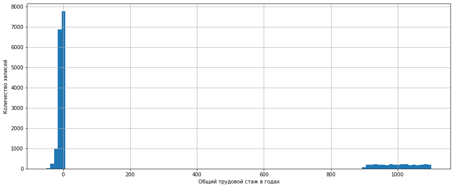

```python
ax = years_employed.hist(bins=100, figsize = (15, 6))
ax.set_xlabel('Общий трудовой стаж в годах')
ax.set_ylabel('Количество записей');
```

Можно предположить два возможных варианта объяснения аномалии данных в поле `days_employed`:

1. В данные закралась ошибка. У пенсионеров и безработных в поле `days_employed` хранятся случайные значения, а у работающих изменнен знак на противоположный.
2. В поле `days_employed` хранится не заявленный в спецификации общий трудовой стаж в днях, а значение какой-то функции многих переменных, характеризующей надежность источника дохода потенциального клиента. Данная функция вероятно зависит не только от трудового стажа, но и пенсионного статуса.

Не имея возможности связаться с поставщиком данных, будем далее исходить из первого варианта.

Скорректируем поле `days_employed`, сохранив его копию в `days_employed_backup` на будущее, следующим образом:

- для пенсионеров и безработных установим его в ноль;
- для остальных поменяем знак на противоположный;
- пропуски заполним нулями (Исходим из того, что клиент, не указавший доход, снижает свои шансы на получение кредита. В задаче машинного обучения, возможно, пришлось бы заменить пропуски на средние или медианные значения дохода для аналогичной группы клиентов, объединенным по схожести нескольких категориальных признаков).

```python
data['days_employed_backup'] = data['days_employed']
```

```python
data.loc[data['days_employed'] > 0, 'days_employed'] = 0
```

```python
data.loc[data['days_employed'] < 0, 'days_employed'] *= -1
```

```python
data.days_employed.fillna(0, inplace=True)
```

Убедимся в отсутствии пропусков в поле `days_employed`:

```python
data.days_employed.isna().sum()
```

```
0
```

В дальнейшем можно пересчитать поле `days_employed`, если у банка изменится стратегия предоставления кредитов. Сейчас, обнулив пропуски в стаже, мы придерживаемся жестких правил, направленных на снижение риска невозврата займа. Если банк будет располагать финансовыми возможностями для игры на привлечение новых клиентов и повышение доходов, то мы будем рассматривать обращение потенциального заемщика с отсутствующими по каким-либо причинам данными о стаже, вычислив их на основе средних для похожих по некоторым категориям клиентов. Но для этого ниже необходимо определить эти категории (источник дохода, возраст и т.п.). А пока политика банка жесткая ограничимся обнулением пропусков в данных.

##### Проверка адекватности полученных данных по стажу работы

Проверим адекватность полученных данных, вычислив на их основе возраст начала трудовой деятельности клиентов. Переведем стаж в года и вычтем из возраста. Округлим до целых:

```python
work_start_age = (data.dob_years -  data.days_employed / 365).round(decimals=0)
```

Посчитаем количество записей с неадекватным возрастом начала трудовой деятельности:

```python
# зададим адекватный возраст
appropriate_age = 14
print('Список неадекватных возрастов и их количество в наборе данных:')
display(work_start_age[work_start_age < appropriate_age].value_counts().sort_values(ascending=False))
```

```
Список неадекватных возрастов и их количество в наборе данных:
```

```
 0.0     30
-3.0     12
-4.0     10
-1.0      9
-2.0      8
-5.0      7
-7.0      5
 13.0     5
 12.0     4
-12.0     3
-6.0      3
-13.0     3
-10.0     2
-9.0      2
-29.0     2
-14.0     2
 11.0     2
-16.0     1
-22.0     1
-18.0     1
dtype: int64
```

```python
inadequate_count = work_start_age[work_start_age < appropriate_age].count()
print('Количество записей с неадекватным соотношением стажа и возраста:', inadequate_count)
```

```
Количество записей с неадекватным соотношением стажа и возраста: 112
```

```python
print('Доля записей с неадекватным соотношением стажа и возраста: {:.2%}'.format(inadequate_count / data.shape[0]))
```

```
Доля записей с неадекватным соотношением стажа и возраста: 0.52%
```

Встречаются даже отрицательные значения. Неадекватноое соотношение стажа и возраста у небольшого количества записей может быть вызвано ошибками ввода данных операторами в поля `dob_years` и `data.days_employed` или сообщением клиентами недостоверных сведений о себе.

Удаление этих записей не скажется на результатах далнейшей работы (их доля меньше одного процента). Воспользуемся функцией [`drop`](https://pandas.pydata.org/pandas-docs/stable/reference/api/pandas.DataFrame.drop.html):

```python
data.drop(work_start_age[work_start_age < appropriate_age].index, inplace=True)
```

#### Поле total_income (ежемесячный доход)

Оценим количество и долю пропусков в данных о ежемесячном доходе:

```python
print('Количество записей с пропусками в данных о ежемесячном доходе:', data.total_income.isnull().sum())
```

```
Количество записей с пропусками в данных о ежемесячном доходе: 2164
```

```python
print('Доля записей с пропусками в данных о ежемесячном доходе: '
      '{:.2%}'.format(data.total_income.isnull().sum() / data.shape[0]))
```

```
Доля записей с пропусками в данных о ежемесячном доходе: 10.11%
```

Удаление десятой части данных может негативно сказаться на результатах решения задачи кредитного скоринга при реализации стратегии на привлечение новых клиентов. Мы можем упустить надежного клиента из-за отсутствия в его обращении некоторых данных.

В данном учебном проекте обнулим пропуски, но на будущее заведем в наборе данных признак `calculated_income`, который будет принимать следующие значения: `False` - данные о доходе были представлены в первоначальном наборе, `True` - данные о доходе получены из других признаков заемщика и статистики других клиентов.

```python
data['calculated_income'] = data.total_income.isnull()
```

```python
data.total_income.fillna(0, inplace=True)
```

#### Поле children (количество детей в семье)

В поле `children` (количество детей в семье) обнаружены недопустимое (`-1`) и выбивающееся из ряда (`20`) значения:

```python
data.children.value_counts().sort_index()
```

```
-1        47
 0     14071
 1      4800
 2      2042
 3       328
 4        41
 5         9
 20       75
Name: children, dtype: int64
```

Изучим распределение возраста клиентов с разным количеством детей:

```python
data.pivot_table(index = 'children', values = 'dob_years', aggfunc=['min', 'mean', 'max', ])
```

| children | min dob_years | mean dob_years | max dob_years |
| --- | --- | --- | --- |
| -1 | 23 | 42.574468 | 69 |
| 0 | 19 | 46.488949 | 75 |
| 1 | 20 | 38.491250 | 73 |
| 2 | 20 | 35.998041 | 64 |
| 3 | 23 | 36.509146 | 63 |
| 4 | 24 | 36.048780 | 51 |
| 5 | 31 | 38.777778 | 59 |
| 20 | 21 | 42.373333 | 69 |

Обнаружено подтверждение искажения некоторых данных - самому молодому родителю двадцати детей исполнился лишь 21 год. Исходя из оптимистичного здравого смысла, такого выдающегося результата можно в лучшем случае достичь годам к 30.

В учебных целях будем считать, что мы проверили ряд гипотез о причинах искажения данных. Было установлено, что `-1` - неправильно распознанные сканером четверки `4` (автор программы не закончил в своё время курсы [Яндекс.Практикум](https://praktikum.yandex.ru/), а `20` - ошибки операторов при вводе с клавиатуры (при нажатии на клавишу `2` в правой части 105-клавишной клавиатуры они иногда случайно задевали ещё и `0`, расположенный чуть ниже).

[figure not shown]

Исправим обнаруженные опечатки:

```python
data.loc[data.children == -1, 'children'] = 4
```

```python
data.loc[data.children == 20, 'children'] = 2
```

Теперь поле `children` (количество детей в семье) не содержит аномалий:

```python
data.children.value_counts().sort_index()
```

```
0    14071
1     4800
2     2117
3      328
4       88
5        9
Name: children, dtype: int64
```

### Вывод

1. Значения в поле `days_employed` (общий трудовой стаж в днях) пересчитаны в соответствии с его предназначением. Исправлены искажения в данных. Первоначальные данные сохранены в `days_employed_backup` для возможного использования в дальнейшем.
2. После восстановления пропусков удалены записи с неадекватным возрастом начала трудовой деятельности.
3. Пропуски в полях `days_employed` (общий трудовой стаж в днях) и `total_income` (ежемесячный доход) заполнены нулевыми значениями.
4. Заведено поле `calculated_income` с признаком обнуления поля `total_income` для возможности при необходимости заменить нули на оценку дохода по статистике других клиентов.
5. Исправлены опечатки в полях с информацией о количестве детей (`children`) в анкетах кандидатов.

### Замена типа данных

#### Поле days_employed (общий трудовой стаж в днях)

```python
data.astype({'days_employed': 'int64'}).dtypes
```

```
children                  int64
days_employed             int64
dob_years                 int64
education                object
education_id              int64
family_status            object
family_status_id          int64
gender                   object
income_type              object
debt                      int64
total_income            float64
purpose                  object
days_employed_backup    float64
calculated_income          bool
dtype: object
```

#### Поле gender (пол клиента)

В наборе данных присутствуют записи с отклонением от естественных вариантов пола. Помимо мужского (M) и женского (F) обнаружена одна запись с отметкой XNA, о значении которой можно только догадываться (возможно, "третий пол"):

```python
data.gender.value_counts()
```

```
F      14154
M       7258
XNA        1
Name: gender, dtype: int64
```

```python
data[data.gender == 'XNA']
```

|  | children | days_employed | dob_years | education | education_id | family_status | family_status_id | gender | income_type | debt | total_income | purpose | days_employed_backup | calculated_income |
| --- | --- | --- | --- | --- | --- | --- | --- | --- | --- | --- | --- | --- | --- | --- |
| 10701 | 0 | 2358.600502 | 24 | неоконченное высшее | 2 | гражданский брак | 1 | XNA | компаньон | 0 | 203905.157261 | покупка недвижимости | -2358.600502 | False |

В учебных целях не будем принимать во внимание толерантность и удалим эту запись:

```python
data.drop(data[data.gender == 'XNA'].index, inplace=True)
```

```python
data[data.gender == 'XNA'].count()
```

```
children                0
days_employed           0
dob_years               0
education               0
education_id            0
family_status           0
family_status_id        0
gender                  0
income_type             0
debt                    0
total_income            0
purpose                 0
days_employed_backup    0
calculated_income       0
dtype: int64
```

Оперировать данными логического типа, как представляется, удобнее. Cоздадим новое поле `gender_male` логического типа со значениями `True` для мужского пола и `False` - для женского. Воспользуемся функцией [`astype`](https://pandas.pydata.org/pandas-docs/stable/reference/api/pandas.DataFrame.astype.html):

```python
data['gender_male'] = (data.gender == 'M').astype('bool')
```

Избыточное поле `gender` теперь можно удалить из набора данных с помощью функции [`drop`](https://pandas.pydata.org/pandas-docs/stable/reference/api/pandas.DataFrame.drop.html):

```python
data.drop(columns='gender', inplace=True, errors='ignore')
```

#### Поле debt (имел ли задолженность по возврату кредитов)

Изменим тип поля `debt` (имел ли задолженность по возврату кредитов) на логический. Проконтролируем выполнение:

```python
data.astype({'debt': 'bool'}).dtypes
```

```
children                  int64
days_employed           float64
dob_years                 int64
education                object
education_id              int64
family_status            object
family_status_id          int64
income_type              object
debt                       bool
total_income            float64
purpose                  object
days_employed_backup    float64
calculated_income          bool
gender_male                bool
dtype: object
```

### Обработка дубликатов

#### Удаление полных дубликатов

Изучим образцы дубликатов и убедимся в их ненужности для дальнейшей работы:

```python
data[data.duplicated(keep=False)].head(5)
```

|  | children | days_employed | dob_years | education | education_id | family_status | family_status_id | income_type | debt | total_income | purpose | days_employed_backup | calculated_income | gender_male |
| --- | --- | --- | --- | --- | --- | --- | --- | --- | --- | --- | --- | --- | --- | --- |
| 120 | 0 | 0.0 | 46 | среднее | 1 | женат / замужем | 0 | сотрудник | 0 | 0.0 | высшее образование | NaN | True | False |
| 520 | 0 | 0.0 | 35 | среднее | 1 | гражданский брак | 1 | сотрудник | 0 | 0.0 | сыграть свадьбу | NaN | True | False |
| 541 | 0 | 0.0 | 57 | среднее | 1 | женат / замужем | 0 | сотрудник | 0 | 0.0 | сделка с подержанным автомобилем | NaN | True | False |
| 554 | 0 | 0.0 | 60 | среднее | 1 | женат / замужем | 0 | сотрудник | 0 | 0.0 | покупка недвижимости | NaN | True | True |
| 680 | 1 | 0.0 | 30 | высшее | 0 | женат / замужем | 0 | госслужащий | 0 | 0.0 | покупка жилья для семьи | NaN | True | False |

Возможные причины появления полных дубликатов:

- неоднократное обращение одного клиента за кредитом (в разное время и/или в разных отделениях банка);
- ввод данных одного заявления несколько раз из-за ошибки оператора;
- за кредитом могли обращаться люди с некоторыми одинаковыми данными. Идентифицировать их можно только по отсутствующим персональным данным, которые были скрыты от аналитика в соответствии с требованиями законодательства.

Удалим полные дубликаты с помощью функции [`drop_duplicates`](https://pandas.pydata.org/docs/reference/api/pandas.DataFrame.drop_duplicates.html), оставив в наборе данных только уникальные строки:

```python
data.drop_duplicates(inplace=True)
```

Убедимся в отсутствии дубликатов:

```python
data.duplicated().sum()
```

```
0
```

#### Поля education (уровень образования клиента) и education_id (идентификатор уровня образования клиента)

Поля `education` (уровень образования клиента) и `education_id` (идентификатор уровня образования клиента) дублируют друг друга по смысловому содержанию. Только в поле `education` встречаются одинаковые строки, записанные в разной форме. Возможная причина - массив готовили разные люди, которые по разному вводили текстовые данные, а их контроль в программе не осуществлялся:

```python
data.groupby(by=['education_id', 'education'], sort=True)['education_id'].count()
```

```
education_id  education
0             ВЫСШЕЕ                   272
              Высшее                   266
              высшее                  4677
1             СРЕДНЕЕ                  770
              Среднее                  708
              среднее                13636
2             НЕОКОНЧЕННОЕ ВЫСШЕЕ       29
              Неоконченное высшее       47
              неоконченное высшее      665
3             НАЧАЛЬНОЕ                 17
              Начальное                 15
              начальное                250
4             УЧЕНАЯ СТЕПЕНЬ             1
              Ученая степень             1
              ученая степень             4
Name: education_id, dtype: int64
```

Для упрощения обработки можно преобразовать оба поля в словарь, переведя `education` в нижний регистр. Применим функции [`groupby`](https://pandas.pydata.org/docs/reference/api/pandas.DataFrame.groupby.html), [`first`](https://pandas.pydata.org/docs/reference/api/pandas.core.groupby.GroupBy.first.html), [`str.lower`](https://pandas.pydata.org/docs/reference/api/pandas.Series.str.lower.html) и [`to_dict`](https://pandas.pydata.org/docs/reference/api/pandas.DataFrame.to_dict.html):

```python
education_dict = data.groupby(by='education_id', sort=True)['education'].first().str.lower().to_dict()
print('Словарь образования education_dict:', education_dict)
```

```
Словарь образования education_dict: {0: 'высшее', 1: 'среднее', 2: 'неоконченное высшее', 3: 'начальное', 4: 'ученая степень'}
```

Если в задании не накладывается ограничений на поле `education_id` (идентификатор уровня образования клиента), то ему можно придать большее смысловое значение, сопоставив с отсортированным по значимости набором уровеней образования ('начальное', 'среднее', 'неоконченное высшее', 'высшее', 'ученая степень') - чем выше образование, тем больше `education_id`:

```python
# опишем уровни образования в новом порядке
educations = ('начальное', 'среднее', 'неоконченное высшее', 'высшее', 'ученая степень')
```

```python
# обновим поле в соответствии с новым порядком уровней образования
data['education_id'] = data['education'].str.lower().apply(func=lambda e: educations.index(e))
```

Перестроим словарь `education_dict` и убедимся в его корректности:

```python
education_dict = data.groupby(by='education_id', sort=True)['education'].first().str.lower().to_dict()
print('Словарь образования education_dict:', education_dict)
```

```
Словарь образования education_dict: {0: 'начальное', 1: 'среднее', 2: 'неоконченное высшее', 3: 'высшее', 4: 'ученая степень'}
```

```python
print('Список ключей в словаре образования:', list(education_dict.keys()))
print('  Список значений поля education_id:', sorted(list(data['education_id'].unique())))
```

```
Список ключей в словаре образования: [0, 1, 2, 3, 4]
  Список значений поля education_id: [0, 1, 2, 3, 4]
```

Избыточное поле `education` теперь можно удалить из набора данных с помощью функции [`drop`](https://pandas.pydata.org/pandas-docs/stable/reference/api/pandas.DataFrame.drop.html):

```python
data.drop(columns='education', inplace=True, errors='ignore')
```

#### Поля family_status (семейное положение) и family_status_id (идентификатор семейного положения)

Поля `family_status` (семейное положение) и `family_status_id` (идентификатор семейного положения) дублируют друг друга по смысловому содержанию:

```python
data.groupby(by=['family_status_id', 'family_status'], sort=True)['family_status_id'].count()
```

```
family_status_id  family_status
0                 женат / замужем          12285
1                 гражданский брак          4140
2                 вдовец / вдова             954
3                 в разводе                 1185
4                 Не женат / не замужем     2794
Name: family_status_id, dtype: int64
```

Для упрощения обработки можно преобразовать оба поля в словарь, переведя `family_status` в нижний регистр. Применим функции [`groupby`](https://pandas.pydata.org/docs/reference/api/pandas.DataFrame.groupby.html), [`first`](https://pandas.pydata.org/docs/reference/api/pandas.core.groupby.GroupBy.first.html), [`str.lower`](https://pandas.pydata.org/docs/reference/api/pandas.Series.str.lower.html) и [`to_dict`](https://pandas.pydata.org/docs/reference/api/pandas.DataFrame.to_dict.html):

```python
family_status_dict = data.groupby(by='family_status_id', sort=True)['family_status'].first().str.lower().to_dict()
print('Словарь семейного положения family_status_dict:')
print(family_status_dict)
```

```
Словарь семейного положения family_status_dict:
{0: 'женат / замужем', 1: 'гражданский брак', 2: 'вдовец / вдова', 3: 'в разводе', 4: 'не женат / не замужем'}
```

```python
family_status_to_id_dict = dict(zip(family_status_dict.values(), family_status_dict.keys()))
print('Словарь идентификаторов семейного положения family_status_to_id_dict:')
print(family_status_to_id_dict)
```

```
Словарь идентификаторов семейного положения family_status_to_id_dict:
{'женат / замужем': 0, 'гражданский брак': 1, 'вдовец / вдова': 2, 'в разводе': 3, 'не женат / не замужем': 4}
```

Избыточное поле `family_status` теперь можно удалить из набора данных с помощью функции [`drop`](https://pandas.pydata.org/pandas-docs/stable/reference/api/pandas.DataFrame.drop.html):

```python
data.drop(columns='family_status', inplace=True, errors='ignore')
```

#### Поле income_type (тип занятости)

Поле `income_type` (тип занятости) содержит много текстовых дубликатов:

```python
data.income_type.value_counts()
```

```
сотрудник          11027
компаньон           5057
пенсионер           3817
госслужащий         1451
безработный            2
предприниматель        2
студент                1
в декрете              1
Name: income_type, dtype: int64
```

Полученный массив данных не содержит смысловых ошибок, по крайней мере, мужчин в декрете не обнаружено:

```python
data.loc[(data.income_type == 'в декрете') & (data.gender_male)]['gender_male'].count()
```

```
0
```

Целесообразно избавиться от избыточности дублированных текстовых данных и перейти к словарю, который будет одновременно классифицировать клиентов по типу занятости:

```python
items = list(data.income_type.unique())
keys  = list(range(len(items)))

income_type_dict = dict(zip(keys, items))
print('Словарь типов занятости income_type_dict:')
display(income_type_dict)
```

```
Словарь типов занятости income_type_dict:
```

```
{0: 'сотрудник',
 1: 'пенсионер',
 2: 'компаньон',
 3: 'госслужащий',
 4: 'безработный',
 5: 'предприниматель',
 6: 'студент',
 7: 'в декрете'}
```

```python
income_type_to_id_dict = dict(zip(items, keys))
print('Словарь идентификаторов типов занятости income_type_to_id_dict:')
display(income_type_to_id_dict)
```

```
Словарь идентификаторов типов занятости income_type_to_id_dict:
```

```
{'сотрудник': 0,
 'пенсионер': 1,
 'компаньон': 2,
 'госслужащий': 3,
 'безработный': 4,
 'предприниматель': 5,
 'студент': 6,
 'в декрете': 7}
```

Создадим в наборе данных новое поле `income_type_id` (идентификатор типа занятости):

```python
data['income_type_id'] = data.income_type.apply(func=lambda t: dict(zip(items, keys))[t])
```

Избыточное поле `income_type` теперь можно удалить из набора данных с помощью функции [`drop`](https://pandas.pydata.org/pandas-docs/stable/reference/api/pandas.DataFrame.drop.html):

```python
data.drop(columns='income_type', inplace=True, errors='ignore')
```

### Вывод

1. Удалены полные дубликаты строк массива данных, т.к. в данной задаче их обработка привела бы к лишним операциям без улучшения качества решения.
2. Исправлены написанные разным регистром дубликаты в полях, что избавит от ошибок обработки данных в дальнейшем анализе.

В соответствии с полученным советом **оценим количество и долю дубликатов** в массиве данных с помощью функции [`duplicated`](https://pandas.pydata.org/docs/reference/api/pandas.DataFrame.duplicated.html):

```python
print('Количество записей, имеющих полные дубликаты:', data.duplicated().sum())
```

```
Количество записей, имеющих полные дубликаты: 17
```

```python
print('Доля полных дубликатов: {:.2%}'.format(data.duplicated().sum() / data.shape[0]))
```

```
Доля полных дубликатов: 0.08%
```

Удалим полные дубликаты с помощью функции [`drop_duplicates`](https://pandas.pydata.org/docs/reference/api/pandas.DataFrame.drop_duplicates.html), оставив в наборе данных только уникальные строки:

```python
data.drop_duplicates(inplace=True)
```

Убедимся в отсутствии дубликатов:

```python
data.duplicated().sum()
```

```
0
```

**Вывод по совету**: поиск полных дубликатов лучше производить после нормализации и категоризации отдельных полей.

### Лемматизация

Проведем [лемматизацию](https://ru.wikipedia.org/wiki/%D0%9B%D0%B5%D0%BC%D0%BC%D0%B0%D1%82%D0%B8%D0%B7%D0%B0%D1%86%D0%B8%D1%8F) текста в поле `purpose` (цель получения кредита) с помощью библиотеки [pymorphy2](https://pymorphy2.readthedocs.io/). Её быстроты вполне достаточно для данной учебной задачи. А качество pymystem3 прибережем для будущих серьезных проектов. В учебных целях разработаем свои функции и не будем обращаться к библиотеке [Natural Language Toolkit](https://www.nltk.org/), которая могла бы существенно упростить работу.

```python
import pymorphy2
```

Используем счетчик Counter из библиотеки [collections](https://docs.python.org/3.8/library/collections.html) для подсчета частоты встречаемости слов в текстовом описании целей получения кредита:

```python
from collections import Counter
```

Для разделения слов используем [регулярные выражения](https://ru.wikipedia.org/wiki/%D0%A0%D0%B5%D0%B3%D1%83%D0%BB%D1%8F%D1%80%D0%BD%D1%8B%D0%B5_%D0%B2%D1%8B%D1%80%D0%B0%D0%B6%D0%B5%D0%BD%D0%B8%D1%8F) и библиотеку [re](https://docs.python.org/3.8/library/re.html):

```python
import re
```

**Опишем функцию лемматизации одной строки:**

```python
def lemmatize_text(text, min_len=1, pymorph=None, global_counter=None, words_count=3, synonyms=None):
    """
    Функция производит лемматизацию строки text с помощью лемматизатора pymorph (pymorphy2.MorphAnalyzer).
    Во внимание принимаются только русские буквы. Все остальные символы считаются разделителями.
    Если pymorph не задан использует свой экземпляр pymorphy2.MorphAnalyzer.
    stemmer целесообразно задавать при обработке больших массивов Pandas или в цикле для сокращения общего
    времени выполнения.
    Если задан счетчик global_counter (collections.Counter), то в него добавляются кортежи размера не больше
    words_count, состоящие из найденых рядом нормальных форм и их частота упоминания.

    Возвращает строку с нормальными формами слов из строки text, разделенными пробелами.
    Нормальные формы длиною меньше min_len опускаются.
    """
    # создадим лемматизатор, если он не задан
    if pymorph is None:
        pymorph = pymorphy2.MorphAnalyzer()

    # получим список нормальных форм всех слов из русских букв
    words = [pymorph.parse(w)[0].normal_form for w in re.findall(r'[а-яё]+', text.lower())]

    # оставим только нормальные формы длиной не менее min_len
    words = [w for w in words if len(w) >= min_len]

    # при необходимости заменяем синонимы
    if synonyms is not None:
        words = [synonyms[w] if w in synonyms else w for w in words]
        words = [w for w in words if w is not None]


    # обновим внешний счетчик
    if global_counter is not None:
        # построим кортежи слов подряд длиной words_count (или меньше, если нормальных форм обнаружилось меньше)
        word_tuples = [tuple(words[i : i + words_count]) for i in range(max(1, len(words) - words_count + 1))]
        # увеличим частоты встречаемости кортежей слов
        global_counter += Counter(word_tuples)

    # вернем нормальные формы через пробел
    return ' '.join(words)
```

Проверим её работоспособность:

```python
test_text = 'Ехали медведи на велосипеде, а   за  ними мы с Питоном, Пандами и Юпитером, разговаривая в Слэке и ' \
            'почитывая Notion, и официальную документацию!'
```

```python
lemmatize_text(test_text)
```

```
'ехать медведь на велосипед а за они мы с питон панда и юпитер разговаривать в слэк и почитывать и официальный документация'
```

А теперь проведем лемматизацию с заменой синонимов, исключая слово официальный и принимая нормы длиной не меньше 3 символов:

```python
synonyms = {'медведь': 'животное', 'питон': 'язык', 'панда': 'библиотека', 'юпитер': 'программа', 'официальный': None}
```

```python
lemmatize_text(test_text, min_len=3, synonyms=synonyms)
```

```
'ехать животное велосипед они язык библиотека программа разговаривать слэк почитывать документация'
```

**Опишем функцию лемматизации столбца таблицы Pandas:**

```python
def lemmatize_pandas_column(data, column, min_len=1, words_count=3, synonyms=None):
    """
    Сканирует столбец с именем column таблицы data.
    Возвращает лемматизированный столбец Pandas и счетчик упоминаемости нормальных форм фраз длиной words_count слов
    длиной не более min_len символов.
    """
    # создадим экземпляр лемматизатора
    pymorph = pymorphy2.MorphAnalyzer()

    # обнулим счетчик
    purposes_dict = Counter()

    # возвратим лемматизированный столбец и частоты фраз в нем
    return data[column].apply(func=lambda x :
                              lemmatize_text(x, min_len, pymorph, purposes_dict, words_count, synonyms)), \
           purposes_dict
```

**Проведем лемматизацию, игнорируя слова короче трёх символов. Нормализованный текст с описанием цели кредита поместим в новое поле `purpose_norm`:**

```python
data['purpose_norm'], purposes_dict_3_1 = lemmatize_pandas_column(data, 'purpose', 3, 1)
```

Видим, что нормализованный словарь целей кредита имеет вполне конечный размер:

```python
sorted(purposes_dict_3_1.items(), key=lambda x: x[1], reverse=True)
```

```
[(('недвижимость',), 6321),
 (('покупка',), 5867),
 (('жильё',), 4435),
 (('автомобиль',), 4283),
 (('образование',), 3993),
 (('операция',), 2591),
 (('свадьба',), 2309),
 (('свой',), 2223),
 (('строительство',), 1871),
 (('высокий',), 1365),
 (('получение',), 1307),
 (('коммерческий',), 1305),
 (('для',), 1286),
 (('жила',), 1223),
 (('подержать',), 962),
 (('сделка',), 938),
 (('дополнительный',), 901),
 (('заняться',), 900),
 (('проведение',), 764),
 (('сыграть',), 760),
 (('сдача',), 649),
 (('семья',), 637),
 (('собственный',), 632),
 (('ремонт',), 605),
 (('приобретение',), 459),
 (('профильный',), 435)]
```

В нём встречаются синонимы, например "*покупка*" и "*приобретение*".

А вот так выглядит текст после нормализации:

```python
display(data['purpose_norm'])
```

```
0                     покупка жильё
1           приобретение автомобиль
2                     покупка жильё
3        дополнительный образование
4                   сыграть свадьба
                    ...
21520                операция жильё
21521             сделка автомобиль
21522                  недвижимость
21523       покупка свой автомобиль
21524            покупка автомобиль
Name: purpose_norm, Length: 21341, dtype: object
```

**Проведем лемматизацию, игнорируя слова короче трёх символов и объединяя их по возможности в биграммы:**

Объединим близкие по смыслу слова и удалим незначащие, используя словарь синонимов:

```python
purpose_synonyms = {'приобретение': 'покупка', 'операция': 'сделка', 'сдача': 'сделка', 'жила': 'жильё',
                    'проведение': None, 'сыграть': None, 'подержать': None, 'свой': None, 'собственный': None,
                    'заняться': None, 'получение': None}
```

```python
data['purpose_norm'], purposes_dict_3_2 = lemmatize_pandas_column(data, 'purpose', 3, 2, purpose_synonyms)
```

Размер словаря существенно не увеличился:

```python
print('Размер словаря фраз из одного слова:', len(purposes_dict_3_1))
print('Размер словаря фраз до двух слов:   ', len(purposes_dict_3_2))
```

```
Размер словаря фраз из одного слова: 26
Размер словаря фраз до двух слов:    24
```

```python
sorted(purposes_dict_3_2.items(), key=lambda x: x[1], reverse=True)
```

```
[(('покупка', 'жильё'), 3147),
 (('свадьба',), 2309),
 (('покупка', 'автомобиль'), 1905),
 (('автомобиль',), 1440),
 (('высокий', 'образование'), 1365),
 (('коммерческий', 'недвижимость'), 1305),
 (('сделка', 'недвижимость'), 1298),
 (('образование',), 1292),
 (('жильё', 'для'), 1286),
 (('строительство', 'недвижимость'), 1251),
 (('жильё', 'недвижимость'), 1223),
 (('сделка', 'автомобиль'), 938),
 (('дополнительный', 'образование'), 901),
 (('покупка', 'коммерческий'), 658),
 (('для', 'сделка'), 649),
 (('сделка', 'коммерческий'), 647),
 (('сделка', 'жильё'), 646),
 (('жильё',), 640),
 (('для', 'семья'), 637),
 (('недвижимость',), 628),
 (('строительство', 'жильё'), 620),
 (('покупка', 'недвижимость'), 616),
 (('ремонт', 'жильё'), 605),
 (('профильный', 'образование'), 435)]
```

**Проведем лемматизацию, игнорируя слова короче трёх символов и объединяя их по возможности в триграммы:**

```python
data['purpose_norm'], purposes_dict_3_3 = lemmatize_pandas_column(data, 'purpose', 3, 3, purpose_synonyms)
```

Размер словаря существенно не изменился:

```python
print('Размер словаря фраз из одного слова:', len(purposes_dict_3_1))
print('Размер словаря фраз до двух слов:   ', len(purposes_dict_3_2))
print('Размер словаря фраз до трех слов:   ', len(purposes_dict_3_3))
```

```
Размер словаря фраз из одного слова: 26
Размер словаря фраз до двух слов:    24
Размер словаря фраз до трех слов:    23
```

Изучим словарь фраз лемматизированных целей кредита, отсортировав их по популярности:

```python
sorted(purposes_dict_3_3.items(), key=lambda x: x[1], reverse=True)
```

```
[(('свадьба',), 2309),
 (('покупка', 'автомобиль'), 1905),
 (('автомобиль',), 1440),
 (('высокий', 'образование'), 1365),
 (('сделка', 'недвижимость'), 1298),
 (('образование',), 1292),
 (('покупка', 'жильё', 'для'), 1286),
 (('покупка', 'жильё'), 1258),
 (('строительство', 'недвижимость'), 1251),
 (('сделка', 'автомобиль'), 938),
 (('дополнительный', 'образование'), 901),
 (('покупка', 'коммерческий', 'недвижимость'), 658),
 (('жильё', 'для', 'сделка'), 649),
 (('сделка', 'коммерческий', 'недвижимость'), 647),
 (('сделка', 'жильё'), 646),
 (('жильё',), 640),
 (('жильё', 'для', 'семья'), 637),
 (('недвижимость',), 628),
 (('строительство', 'жильё', 'недвижимость'), 620),
 (('покупка', 'недвижимость'), 616),
 (('ремонт', 'жильё'), 605),
 (('покупка', 'жильё', 'недвижимость'), 603),
 (('профильный', 'образование'), 435)]
```

Малое увеличение словаря при увеличении размера картежа от одного до трех слов позволяет предположить, что категоризацию цели кредита можно осуществить по небольшому списку ключевых слов, наиболее точно описывающих ту или иную категорию. В данной работе не будем применять более эффективные, но сложные алгоритмы, оставив их на предстоящие специальные курсы.

### Вывод

Проведена лемматизация текста в поле с описанием цели кредита. Создан новый столбец с нормальными формами слов. В дальнейшем можно проводить категоризацию целей, выполняя поиск по ключевым словам в новом поле.

### Категоризация данных

#### Категоризация по цели кредита

Просмотрев словарь лемматизированных целей кредита сформулируем принцип классификации, выделив в учебном проекте только наиболее значимые причины обращения за займом и их признаки. Оформим поясняющую таблицу:

[output not shown]

Выполним категоризацию по типу займа, разделив их на два класса **Займ для сделки** и **Займ для себя**, в зависимости от упоминания в цели слова 'сделка':

```python
def is_for_contract(s):
    return s.find('сделка') != -1
```

```python
data['for_contract'] = data['purpose_norm'].apply(is_for_contract)
```

```python
data[['purpose_norm', 'for_contract']]
```

|  | purpose_norm | for_contract |
| --- | --- | --- |
| 0 | покупка жильё | False |
| 1 | покупка автомобиль | False |
| 2 | покупка жильё | False |
| 3 | дополнительный образование | False |
| 4 | свадьба | False |
| ... | ... | ... |
| 21520 | сделка жильё | True |
| 21521 | сделка автомобиль | True |
| 21522 | недвижимость | False |
| 21523 | покупка автомобиль | False |
| 21524 | покупка автомобиль | False |

21341 rows × 2 columns

Выполним категоризацию **по типу объекту займа**, разделив их на несколько классов, в зависимости от упоминания в цели соответствующих ключевых слов.

Зададим словарь описаний классов целей и лямбда-функций проверки принадлежности цели этим классам:

```python
object_criteria_dict = {
    'проведение свадьбы':    lambda s : s.find('свадьба') != -1,
    'покупка автомобиля':    lambda s : s.find('автомоб') != -1,
    'получение образования': lambda s : s.find('образов') != -1,
    'строительство':         lambda s : s.find('строит')  != -1,
    'ремонт':                lambda s : s.find('ремонт')  != -1,
    'покупка жилья':         lambda s : s.find('жильё')   != -1,
    'покупка коммерческой недвижимости': lambda s : s.find('недвиж') != -1 and s.find('коммерч') != -1,
    'покупка прочей недвижимости':       lambda s : s.find('недвиж') != -1,
    'прочая цель': True }
```

Зададим словарь кодов описаний классов для их последующего сохранения в поле `purpose_detail_id` набора данных:

```python
object_type_dict = dict(enumerate(object_criteria_dict.keys()))
object_type_dict
```

```
{0: 'проведение свадьбы',
 1: 'покупка автомобиля',
 2: 'получение образования',
 3: 'строительство',
 4: 'ремонт',
 5: 'покупка жилья',
 6: 'покупка коммерческой недвижимости',
 7: 'покупка прочей недвижимости',
 8: 'прочая цель'}
```

Опишем функцию категоризации в соответствии с критериями, определенными выше:

```python
def get_object_type_id(s):
    # возвращаем индекс первого выполненного условия из словаря критериев object_criteria_dict
    for i, criteria in enumerate(object_criteria_dict.items()):
        if criteria[1](s):
            return i
    return None
```

Выполним категоризацию по основной цели займа. Значение кодов класса занесем в поле `purpose_detail_id` набора данных:

```python
data['purpose_detail_id'] = data['purpose_norm'].apply(get_object_type_id)
```

```python
data[['purpose_norm', 'purpose_detail_id']]
```

|  | purpose_norm | purpose_detail_id |
| --- | --- | --- |
| 0 | покупка жильё | 5 |
| 1 | покупка автомобиль | 1 |
| 2 | покупка жильё | 5 |
| 3 | дополнительный образование | 2 |
| 4 | свадьба | 0 |
| ... | ... | ... |
| 21520 | сделка жильё | 5 |
| 21521 | сделка автомобиль | 1 |
| 21522 | недвижимость | 7 |
| 21523 | покупка автомобиль | 1 |
| 21524 | покупка автомобиль | 1 |

21341 rows × 2 columns

Категоризация по цели кредита выполнена. Набор данных теперь можно анализировать по категориям, используя группировку. Посмотрим количество обращений с различными целями:

```python
data.groupby(['for_contract', 'purpose_detail_id']).debt.count()
```

```
for_contract  purpose_detail_id
False         0                    2309
              1                    3345
              2                    3993
              3                    1871
              4                     605
              5                    3138
              6                     658
              7                    1244
True          1                     938
              5                    1295
              6                     647
              7                    1298
Name: debt, dtype: int64
```

#### Категоризация по статусу "многодетная семья"

В Москве [**многодетной признается семья**](https://www.mos.ru/otvet-socialnaya-podderjka/lgoti-mnogodetnim-semyam/), в которой родились и (или) воспитываются **трое и более детей** (в том числе усыновленные, а также пасынки и падчерицы) до достижения младшим из них возраста 16 лет, а обучающимся в образовательной организации, реализующей основные общеобразовательные программы, — 18 лет.

Поместим значение `True` в новое поле `'big_family'` для многодетных семей:

```python
data['big_family'] = data['children'].apply(lambda n: None if n == 0 else n >= 3)
```

```python
print('Количество запросов от многодетных семей:', data.big_family.sum())
```

```
Количество запросов от многодетных семей: 425
```

```python
print('Доля запросов от многодетных семей: {:.2%}'.format(data.big_family.sum() / data.shape[0]))
```

```
Доля запросов от многодетных семей: 1.99%
```

#### Другие категории

При удалении дубликатов выше была фактически проведена категоризация по некоторым признакам:

- уровень образования;
- семейный статус;
- тип занятости.

Проводить категоризацию по уровню дохода на данном этапе не имеет смысла. Это можно делать динамически с помощью функции [`cut`](https://pandas.pydata.org/pandas-docs/stable/reference/api/pandas.cut.html). Воспользуемся ею при оценке зависимости возврата кредита от зарплаты (см. ниже).

### Вывод

Осуществлена категоризация данных. В результате получены новые данные, которые упрощают обработку. Например, неформализованное поле цели получения кредита теперь пригодно для использования численными методами для решения задачи кредитного скоринга.

### Шаг 3. Ответьте на вопросы

### Есть ли зависимость между наличием детей и возвратом кредита в срок?

Изучим изменение доли просроченных кредитов в зависимости от количества детей у клиента.

```python
agg_columns = (('обратились', 'count'), ('не вернули в срок', 'sum'), ('доля просрочки', 'mean'))
bebt_by_children = data.groupby('children')['debt'].agg(agg_columns)
bebt_by_children
```

| children | обратились | не вернули в срок | доля просрочки |
| --- | --- | --- | --- |
| 0 | 14012 | 1058 | 0.075507 |
| 1 | 4790 | 441 | 0.092067 |
| 2 | 2114 | 202 | 0.095553 |
| 3 | 328 | 27 | 0.082317 |
| 4 | 88 | 5 | 0.056818 |
| 5 | 9 | 0 | 0.000000 |

Наблюдается нелинейная зависимость возврата кредита в срок от количества детей у клиента. Больше всего страдают от коллекторов семьи с двумя детьми.

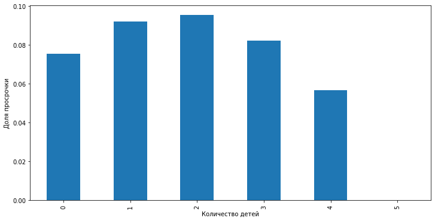

```python
ax = bebt_by_children['доля просрочки'].plot.bar(figsize = (12, 6))
ax.set_xlabel('Количество детей')
ax.set_ylabel('Доля просрочки');
```

Отсортируем клиентов по надежности в зависимости от количества детей в их семье:

```python
for n, i in enumerate(data.groupby('children')['debt'].mean().sort_values().index.tolist()):
    print('{:d}. Количество детей - {:d}'.format(n + 1, i))
```

```
1. Количество детей - 5
2. Количество детей - 4
3. Количество детей - 0
4. Количество детей - 3
5. Количество детей - 1
6. Количество детей - 2
```

Изучим изменение доли просроченных кредитов по категории "многодетная семья".

```python
agg_columns = (('обратились', 'count'), ('не вернули в срок', 'sum'), ('доля просрочки', 'mean'))
bebt_by_family_size = data.groupby('big_family')['debt'].agg(agg_columns)
bebt_by_family_size.index = ['1-2 ребенка', 'многодетные']
bebt_by_family_size
```

|  | обратились | не вернули в срок | доля просрочки |
| --- | --- | --- | --- |
| 1-2 ребенка | 6904 | 643 | 0.093134 |
| многодетные | 425 | 32 | 0.075294 |

### Вывод

1. Наблюдается нелинейная зависимость возврата кредита в срок от количества детей у клиента. Больше всего страдают от коллекторов семьи с двумя детьми.
2. На надежность многодетных семей несомненно влияет их ответственность и государственная поддержка. Но результат не должен нас успокаивать. Семей с большим количеством детей гораздо меньше, чем с 1-2 детьми. Данные по многодетным чувствительны к каждому очередному просроченному платежу этой категории.

### Есть ли зависимость между семейным положением и возвратом кредита в срок?

Изучим изменение доли просроченных кредитов в зависимости от семейного положения.

```python
bebt_by_family_status = data.groupby('family_status_id')['debt'].agg(agg_columns)
bebt_by_family_status.index = family_status_to_id_dict.keys()
bebt_by_family_status
```

|  | обратились | не вернули в срок | доля просрочки |
| --- | --- | --- | --- |
| женат / замужем | 12280 | 927 | 0.075489 |
| гражданский брак | 4128 | 386 | 0.093508 |
| вдовец / вдова | 954 | 62 | 0.064990 |
| в разводе | 1185 | 85 | 0.071730 |
| не женат / не замужем | 2794 | 273 | 0.097709 |

Наблюдается зависимость возврата кредита в срок от семейного положения клиента. Чем меньше штампов в паспорте, тем ненадежнее клиент. Холостяки и наслаждающиеся так называемым "гражданским браком" не спешат выплачивать долги.

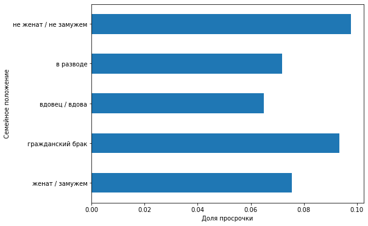

```python
ax = bebt_by_family_status['доля просрочки'].plot.barh(figsize = (8, 6))
ax.set_ylabel('Семейное положение')
ax.set_xlabel('Доля просрочки');
```

Отсортируем клиентов по надежности в зависимости от их семейного положения:

```python
for n, i in enumerate(data.groupby('family_status_id')['debt'].mean().sort_values().index.tolist()):
    print('{:d}. {:s}'.format(n + 1, family_status_dict[i]))
```

```
1. вдовец / вдова
2. в разводе
3. женат / замужем
4. гражданский брак
5. не женат / не замужем
```

### Вывод

Наблюдается зависимость возврата кредита в срок от семейного положения клиента. Чем меньше штампов в паспорте, тем ненадежнее клиент. Холостяки и наслаждающиеся так называемым "гражданским браком" не спешат выплачивать долги.

### Есть ли зависимость между уровнем дохода и возвратом кредита в срок?

Разобъем клиентов на отдельные группы по уровню дохода с помощью функции [`cut`](https://pandas.pydata.org/pandas-docs/stable/reference/api/pandas.cut.html) и попытаемся найти зависимость. Метод разбиения зададим произвольно (на глаз):

```python
bins = [0, 50000, 100000, 150000, 175000, 200000, 300000, 500000, 750000, 1000000, 1500000, 3000000]
labels = ['от {} до {}'.format(bins[i], bins[i+1]-1) for i in range(len(bins)-1)]
bebt_by_income = data.groupby(pd.cut(data.total_income, bins=bins, labels=labels))['debt'].agg(agg_columns)
bebt_by_income.index.name = 'доход'
bebt_by_income
```

| доход | обратились | не вернули в срок | доля просрочки |
| --- | --- | --- | --- |
| от 0 до 49999 | 370 | 23 | 0.062162 |
| от 50000 до 99999 | 4067 | 330 | 0.081141 |
| от 100000 до 149999 | 5678 | 488 | 0.085946 |
| от 150000 до 174999 | 2395 | 216 | 0.090188 |
| от 175000 до 199999 | 1702 | 149 | 0.087544 |
| от 200000 до 299999 | 3558 | 251 | 0.070545 |
| от 300000 до 499999 | 1256 | 92 | 0.073248 |
| от 500000 до 749999 | 173 | 10 | 0.057803 |
| от 750000 до 999999 | 24 | 2 | 0.083333 |
| от 1000000 до 1499999 | 18 | 1 | 0.055556 |
| от 1500000 до 2999999 | 7 | 1 | 0.142857 |

Может показаться, что люди со высоким доходом чаще не возвращают кредиты в срок. Но богатых мало и их статистика может сильно измениться со временем.

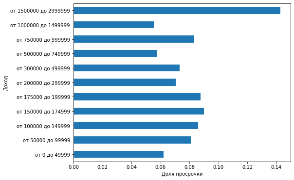

```python
ax = bebt_by_income['доля просрочки'].plot.barh(figsize = (8, 6))
ax.set_ylabel('Доход')
ax.set_xlabel('Доля просрочки');
```

Ошибки кредитного скоринга для многочисленного среднего класса может принести гораздо большие убытки банку. Давайте взглянем на статистику, разделив выборку на четыре примерно одинаковые по размеру группы с помощью функции [quantile](https://pandas.pydata.org/pandas-docs/stable/reference/api/pandas.DataFrame.quantile.html) по [квантилям](https://ru.wikipedia.org/wiki/%D0%9A%D0%B2%D0%B0%D0%BD%D1%82%D0%B8%D0%BB%D1%8C):

```python
p = [0, 0.25, 0.5, 0.75, 1.]
bins = data.total_income.quantile(q=p).astype(int).tolist()
labels = ['от {} до {} ({:.02f}-квантиль)'.format(bins[i], bins[i+1]-1, p[i+1]) for i in range(len(bins)-1)]
bebt_by_income = data.groupby(pd.cut(data.total_income, bins=bins, labels=labels))['debt'].agg(agg_columns)
bebt_by_income.index.name = 'доход'
bebt_by_income
```

| доход | обратились | не вернули в срок | доля просрочки |
| --- | --- | --- | --- |
| от 0 до 89089 (0.25-квантиль) | 3242 | 249 | 0.076804 |
| от 89090 до 135794 (0.50-квантиль) | 5335 | 454 | 0.085098 |
| от 135795 до 195751 (0.75-квантиль) | 5335 | 478 | 0.089597 |
| от 195752 до 2265603 (1.00-квантиль) | 5335 | 382 | 0.071603 |

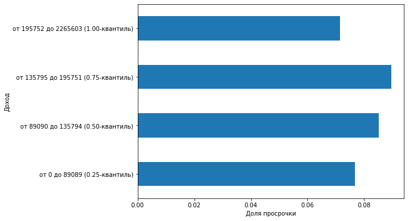

```python
ax = bebt_by_income['доля просрочки'].plot.barh(figsize = (8, 6))
ax.set_ylabel('Доход')
ax.set_xlabel('Доля просрочки');
```

### Вывод

Имеется зависимость между уровнем дохода и возвратом кредита в срок. Наибольшее количество просрочек допускают представители среднего класса.

### Как разные цели кредита влияют на его возврат в срок?

Изучим изменение доли просроченных кредитов в зависимости от их основной цели (целевого объекта).

```python
bebt_by_object = data.groupby(['purpose_detail_id'])['debt'].agg(agg_columns)
bebt_by_object.index = pd.MultiIndex.from_tuples(
    [(object_type_dict[i], ) for i in bebt_by_object.index.tolist()],
    names=['целевой объект'])
bebt_by_object
```

| целевой объект | обратились | не вернули в срок | доля просрочки |
| --- | --- | --- | --- |
| проведение свадьбы | 2309 | 184 | 0.079688 |
| покупка автомобиля | 4283 | 400 | 0.093392 |
| получение образования | 3993 | 370 | 0.092662 |
| строительство | 1871 | 144 | 0.076964 |
| ремонт | 605 | 35 | 0.057851 |
| покупка жилья | 4433 | 312 | 0.070381 |
| покупка коммерческой недвижимости | 1305 | 99 | 0.075862 |
| покупка прочей недвижимости | 2542 | 189 | 0.074351 |

Самыми рискованными для банка выглядят займы на обучение и покупку автомобиля, самыми возвращаемыми в срок - кредиты на ремонт:

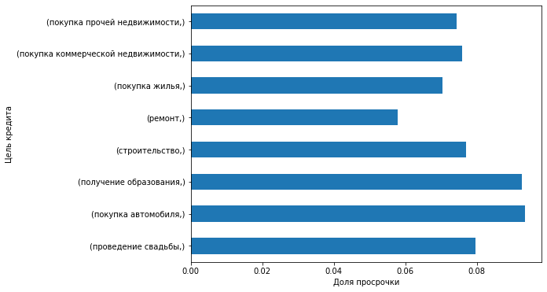

```python
ax = bebt_by_object['доля просрочки'].plot.barh(figsize = (8, 6))
ax.set_ylabel('Цель кредита')
ax.set_xlabel('Доля просрочки');
```

Взглянем на проблему под другим углом. Проанализируем риски, если реализация цели кредита зависит ещё и от третих лиц. Проанализируем сделки отдельно:

```python
bebt_by_purpose = data.groupby(['for_contract', 'purpose_detail_id'])['debt'].agg(agg_columns)
bebt_by_purpose.index = pd.MultiIndex.from_tuples(
    [('сделка' if i[0] else 'без сделки', object_type_dict[i[1]]) for i in bebt_by_purpose.index.tolist()],
    names=['сделка', 'целевой объект'])
bebt_by_purpose
```

| сделка | целевой объект | обратились | не вернули в срок | доля просрочки |
| --- | --- | --- | --- | --- |
| без сделки | проведение свадьбы | 2309 | 184 | 0.079688 |
|  | покупка автомобиля | 3345 | 299 | 0.089387 |
|  | получение образования | 3993 | 370 | 0.092662 |
|  | строительство | 1871 | 144 | 0.076964 |
|  | ремонт | 605 | 35 | 0.057851 |
|  | покупка жилья | 3138 | 213 | 0.067878 |
|  | покупка коммерческой недвижимости | 658 | 47 | 0.071429 |
|  | покупка прочей недвижимости | 1244 | 84 | 0.067524 |
| сделка | покупка автомобиля | 938 | 101 | 0.107676 |
|  | покупка жилья | 1295 | 99 | 0.076448 |
|  | покупка коммерческой недвижимости | 647 | 52 | 0.080371 |
|  | покупка прочей недвижимости | 1298 | 105 | 0.080894 |

Наблюдается изменение зависимости возврата кредита от цели, на которую его хочет потратить клиент, при рассмотрении сделок и обычных займов отдельно.

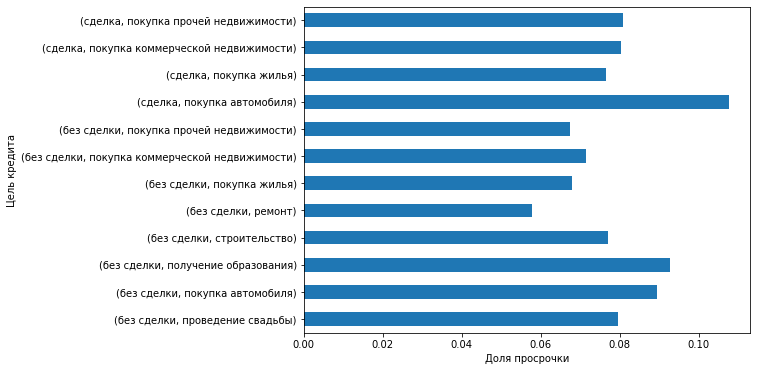

```python
ax = bebt_by_purpose['доля просрочки'].plot.barh(figsize = (8, 6))
ax.set_ylabel('Цель кредита')
ax.set_xlabel('Доля просрочки');
```

Самым рискованным оказывается кредитование сделок с автомобилями.

### Вывод

1. Наблюдается зависимость возврата кредита от цели, на которую его хочет потратить клиент. При этом качество анализа рисков будет существенно зависить от качества лемматизации текста с описанием цели займа, а также правильности выбора принципов категоризации.
2. Самыми рискованными для банка выглядят займы на обучение и покупку автомобиля, самыми возвращаемыми в срок - кредиты на ремонт.
3. Кредиты на прямую покупку автомобилей возвращаюся в срок чаще, чем на сделки с автомобилями.

### Шаг 4. Общий вывод

1. В данной работе на практике закреплены теоретические знания по предобработке данных и выполнены её типовые этапы на примере задачи кредитного скоринга.
2. Установлено, что возврат кредита зависит от многих факторов. Эту зависимость можно обнаружить с помощью простых инструментов обработки данных. Однако точно восстановить зависимость надежности клиента от различных параметров не представляется возможным без специальных численных методов. Их результативность будет во многом зависеть от качества предобработки данных, их лемматизации и категоризации.

### Чек-лист готовности проекта

Поставьте 'x' в выполненных пунктах. Далее нажмите Shift+Enter.

- [x] открыт файл;
- [x] файл изучен;
- [x] определены пропущенные значения;
- [x] заполнены пропущенные значения;
- [x] есть пояснение, какие пропущенные значения обнаружены;
- [x] описаны возможные причины появления пропусков в данных;
- [x] объяснено, по какому принципу заполнены пропуски;
- [x] заменен вещественный тип данных на целочисленный;
- [x] есть пояснение, какой метод используется для изменения типа данных и почему;
- [x] удалены дубликаты;
- [x] есть пояснение, какой метод используется для поиска и удаления дубликатов;
- [x] описаны возможные причины появления дубликатов в данных (причина 1, причина 2);
- [x] выделены леммы в значениях столбца с целями получения кредита;
- [x] описан процесс лемматизации;
- [x] данные категоризированы;
- [x] есть объяснение принципа категоризации данных (принцип 1, принцип 2, другие принципы);
- [x] есть ответ на вопрос: "Есть ли зависимость между наличием детей и возвратом кредита в срок?";
- [x] есть ответ на вопрос: "Есть ли зависимость между семейным положением и возвратом кредита в срок?";
- [x] есть ответ на вопрос: "Есть ли зависимость между уровнем дохода и возвратом кредита в срок?";
- [x] есть ответ на вопрос: "Как разные цели кредита влияют на его возврат в срок?";
- [x] в каждом этапе есть выводы;
- [x] есть общий вывод.